# Cloud Concepts - Principles of cloud computing

This notebook is refer from the Microsoft resources: [Azure fundamentals](https://docs.microsoft.com/en-gb/learn/paths/azure-fundamentals/).

Explore the core concepts of cloud computing and how it can help your business.

### Topic 1: Introduction

#### 1.1 Learning objectives

- Explore common cloud computing services
- Explore the benefits of cloud computing
- Decide which cloud deployment model is best for you

### Topic 2: What is cloud computing?

Cloud computing is renting resources, like storage space or CPU cycles, on another company's computers. You only pay for what you use. The company providing these services is referred to as a cloud provider.

The computing services offered tend to vary by cloud provider. Include:

- **Compute power** - such as *Linux servers* or *web applications*
- **Storage** - such as *files* and *databases*
- **Networking** - such as *secure connections* between the cloud provider and your company
- **Analytics** - such as *visualizing telemetry* and *performance* data

#### 2.1 Cloud computing services

There are two most common services that all cloud providers offer – *compute power* and *storage*.

##### 2.1.1 Compute power

When you build solutions using cloud computing, you can choose how you want work to be done based on your resources and needs.

For example, if you want to have more control and responsibility over maintenance, you could create a virtual machine (VM). A VM is an emulation of a computer - just like your desktop or laptop you're using now. Each VM includes an *operating system* and *hardware* that appears to the user like a physical computer running *Windows or Linux*. **You can then install whatever software you need to do the tasks you want to run in the cloud**.

**The difference is that you don't have to buy any of the hardware or install the OS.** The cloud provider runs your virtual machine on **a physical server in one of their datacenters** - often sharing that server with other VMs (isolated and secure).

**VMs aren't the only computing choice** - there are two other popular options: **containers** and serverless **computing**.

###### 2.1.1.1 What are containers?

**Containers provide a consistent, isolated execution environment for applications**.

They're similar to VMs except they **don't require a guest operating system**. Instead, the application and all **its dependencies is packaged into a "container" and then a standard runtime environment is used to execute the app**. This allows the container to start up in just a few seconds, because there's **no OS to boot and initialize**. You only need the app to launch.

The open-source project, **Docker**, is one of the leading platforms for managing containers. Docker containers provide an *efficient*, *lightweight* approach to application deployment because they **allow different components of the application to be deployed independently into different containers**. Multiple containers can be run on a single machine, and containers can be moved between machines. The **portability** of the container makes it easy for applications to be deployed in multiple environments, either on-premises or in the cloud, often with no changes to the application.

###### 2.1.1.2 What is serverless computing?

**Serverless computing lets you run application code without creating, configuring, or maintaining a server**.

The core idea is that your **application is broken into separate functions** that **run when triggered by some action**. This is ideal for *automated tasks* - for example, you can build a serverless process that automatically sends an email confirmation after a customer makes an online purchase.

[figure not shown]

##### 2.1.2 Storage

[figure not shown]

Most devices and applications read and/or write data. Here are some examples:

- Buying a movie ticket online
- Looking up the price of an online item
- Taking a picture
- Sending an email
- Leaving a voicemail

In all of these cases, data is either read (looking up a price) or written (taking a picture). The type of data and how it's stored can be different in each of these cases.

Cloud providers typically offer services that can handle all of these types of data. For example, if you wanted to store text or a movie clip, you could use a file on disk. If you had a set of relationships such as an address book, you could take a more structured approach like using a database.

The advantage to using cloud-based data storage is **you can scale to meet your needs**. If you find that you need more space to store your movie clips, you can pay a little more and add to your available space. **In some cases, the storage can even expand and contract automatically** - so **you pay for exactly what you need at any given point in time**.

#### 2.2 Summary

Every business has different needs and requirements. Cloud computing is **flexible** and **cost-efficient**, which can be beneficial to every business, whether it's a small start-up or a large enterprise.

### Topic 3: Benefits of cloud computing

Cloud computing isn't an all-or-nothing service approach. **Companies can choose to use the cloud to store their data and execute logic as much, or as little, as necessary to fulfill their business requirements**. Existing businesses might choose a gradual movement to **save money on infrastructure and administration costs** (referred to as "lift and shift"), while a new company might start in the cloud.

#### 3.1 It's cost-effective

[figure not shown]

Cloud computing provides a **pay-as-you-go** or **consumption-based** pricing model.

This consumption-based model brings with it many benefits, including:

- No upfront infrastructure costs
- No need to purchase and manage costly infrastructure that you may not use to its fullest
- The ability to pay for additional resources only when they are needed
- The ability to stop paying for resources that are no longer needed

This also allows for **better cost prediction**. Prices for individual resources and services are provided so you can predict how much you will spend in a given billing period based on your expected usage. You can also **perform analysis based on future growth** using historical usage data tracked by your cloud provider.

#### 3.2 It's scalable

[figure not shown]

You can **increase or decrease the resources and services used based on the demand or workload at any given time**. Cloud computing supports both **vertical and horizontal scaling** depending on your needs.

**Vertical scaling**, also known as "scaling up", is the process of **adding resources to increase the power of an existing server**. Some examples of vertical scaling are: *adding more CPUs*, or *adding more memory*.

**Horizontal scaling**, also known as "scaling out", is the process of **adding more servers that function together as one unit**. For example, you *have more than one server processing incoming requests*.

**Scaling can be done manually or automatically based on specific triggers** such as *CPU utilization* or *the number of requests* and resources that can be allocated or de-allocated in minutes.

#### 3.3 It's elastic

[figure not shown]

As your workload changes due to a spike or drop in demand, a cloud computing system can compensate by automatically adding or removing resources.

For example, imagine your website is featured in a news article, leading to a spike in traffic overnight. Since the cloud is elastic, it automatically allocates more computing resources to handle the increased traffic. When the traffic begins to normalize, the cloud automatically de-allocates the additional resources to minimize cost.

Another example is if you are running an application used by employees, you can have the cloud automatically add resources for the peak operating hours during which most people access the application, and remove the resources at the usual end of the day.

#### 3.4 It's current

[figure not shown]

When you use the cloud, you're able to focus on what matters: **building and deploying applications**. Cloud usage **eliminates the burdens of maintaining software patches, hardware setup, upgrades, and other IT management tasks**. All of this is automatically done for you to ensure you're using the latest and greatest tools to run your business.

Additionally, **the computer hardware is maintained and upgraded by the cloud provider**. For example, if a disk fails, the disk will be replaced by the cloud provider. If a new hardware update becomes available, you don't have to go through the process of replacing your hardware. The cloud provider will ensure that the hardware updates are made available to you automatically.

#### 3.5 It's reliable

[figure not shown]

When you're running a business, you want to be confident your data is always going to be there. **Cloud computing providers offer data backup, disaster recovery, and data replication services to make sure your data is always safe**. In addition, **redundancy** is often built into cloud services architecture so if one component fails, a backup component takes its place. This is referred to as fault tolerance and it ensures that your customers aren't impacted when a disaster occurs.

#### 3.6 It's global

[figure not shown]

Cloud providers have **fully redundant datacenters located in various regions all over the globe**. This gives you a local presence close to your customers to give them the best response time possible no matter where in the world they are.

You can replicate your services into multiple regions for redundancy and locality, or select a specific region to ensure you meet data-residency and compliance laws for your customers.

#### 3.7 It's secure

[figure not shown]

Think about how you secure your datacenter. You have **physical security** – who can access the building, who can operate the server racks, and so on. You also have **digital security** – who can connect to your systems and data over the network.

Cloud providers offer a broad set of policies, technologies, controls, and expert technical skills that can provide better security than most organizations can otherwise achieve. The result is **strengthened security**, *which helps to protect data, apps, and infrastructure from potential threats*.

When it comes to physical security – threats to cloud infrastructure, cloud providers invest heavily in walls, cameras, gates, security personnel, and so on, to protect physical assets. They also have strict procedures in place to ensure employees have access only to those resources that they've been authorized to manage.

Let us talk about digital security. You want only authorized users to be able to log into virtual machines or storage systems running in the cloud. Cloud providers offer tools that help you mitigate security threats, and you must use these tools to protect the resources you use.

#### 3.8 Summary

Cloud computing makes running a business easier. It's **cost-effective, scalable, elastic, current, reliable, and secure**. This means you're able to spend more time on what matters and less time managing the underlying details.

### Topic 4: Compliance terms and requirements

When selecting a cloud provider to host your solutions, you should understand how that provider can help you comply with **regulations** and **standards**. Some questions to ask about a potential provider include:

- How compliant is the cloud provider when it comes to handling sensitive data?
- How compliant are the services offered by the cloud provider?
- How can I deploy my own cloud-based solutions to scenarios that have accreditation or compliance requirements?
- What terms are part of the privacy statement for the provider?

#### 4.1 Compliance Offerings

The following list provides details about some of the compliance offerings available.

- **Criminal Justice Information Services (CJIS)**. Any US state or local agency that wants to access the FBI's CJIS database is required to adhere to the CJIS Security Policy. Azure is the only major cloud provider that contractually commits to conformance with the CJIS Security Policy, which commits Microsoft to adhering to the same requirements that law enforcement and public safety entities must meet.
- **Cloud Security Alliance (CSA) STAR Certification**. Azure, Intune, and Microsoft Power BI have obtained STAR Certification, which involves a rigorous independent third-party assessment of a cloud provider's security posture. This STAR certification is based on achieving ISO/IEC 27001 certification and meeting criteria specified in the Cloud Controls Matrix (CCM). This certification demonstrates that a cloud service provider:
  - Conforms to the applicable requirements of ISO/IEC 27001.
  - Has addressed issues critical to cloud security as outlined in the CCM.
  - Has been assessed against the STAR Capability Maturity Model for the management of activities in CCM control areas.
- **General Data Protection Regulation (GDPR)**. As of May 25, 2018, a European privacy law — GDPR — is in effect. GDPR imposes new rules on companies, government agencies, non-profits, and other organizations that offer goods and services to people in the European Union (EU), or that collect and analyze data tied to EU residents. The GDPR applies no matter where you are located.
- **EU Model Clauses**. Microsoft offers customers EU Standard Contractual Clauses that provide contractual guarantees around transfers of personal data outside of the EU. Microsoft is the first company to receive joint approval from the EU's Article 29 Working Party that the contractual privacy protections Azure delivers to its enterprise cloud customers meet current EU standards for international transfers of data. This ensures that Azure customers can use Microsoft services to move data freely through Microsoft's cloud from Europe to the rest of the world.
- **Health Insurance Portability and Accountability Act (HIPAA)**. HIPAA is a US federal law that regulates patient Protected Health Information (PHI). Azure offers customers a HIPAA Business Associate Agreement (BAA), stipulating adherence to certain security and privacy provisions in HIPAA and the **Health Information Technology for Economic and Clinical Health (HITECH)** Act. To assist customers in their individual compliance efforts, Microsoft offers a BAA to Azure customers as a contract addendum.
- **International Organization for Standardization (ISO) and the International Electrotechnical Commission (IEC) 27018**. Microsoft is the first cloud provider to have adopted the ISO/IEC 27018 code of practice, covering the processing of personal information by cloud service providers.
- **Multi-Tier Cloud Security (MTCS) Singapore**. After rigorous assessments conducted by the MTCS Certification Body, Microsoft cloud services received MTCS 584:2013 certification across all three service classifications:
  - Infrastructure as a Service (IaaS)
  - Platform as a Service (PaaS)
  - Software as a Service (SaaS)

  Microsoft was the first global cloud solution provider (CSP) to receive this certification across all three classifications.
- **Service Organization Controls (SOC) 1, 2, and 3**. Microsoft-covered cloud services are audited at least annually against the SOC report framework by independent third-party auditors. The Microsoft cloud services audit covers controls for data security, availability, processing integrity, and confidentiality as applicable to in-scope trust principles for each service.
- **National Institute of Standards and Technology (NIST) Cybersecurity Framework (CSF)**. NIST CSF is a voluntary Framework that consists of standards, guidelines, and best practices to manage cybersecurity-related risks. Microsoft cloud services have undergone independent, third-party Federal Risk and Authorization Management Program (FedRAMP) Moderate and High Baseline audits, and are certified according to the FedRAMP standards. Additionally, through a validated assessment performed by the Health Information Trust Alliance (HITRUST), a leading security and privacy standards development and accreditation organization, Office 365 is certified to the objectives specified in the NIST CSF.
- **UK Government G-Cloud**. The UK Government G-Cloud is a cloud computing certification for services used by government entities in the United Kingdom. Azure has received official accreditation from the UK Government Pan Government Accreditor.

### Topic 5: Economies of scale

[figure not shown]

Economies of scale is the ability to **do things more efficiently or at a lower-cost per unit when operating at a larger scale**. This cost advantage is an important benefit in cloud computing.

Cloud providers such as Microsoft, Google, and Amazon are large businesses leveraging the benefits of economies of scale. These providers can then pass the savings on to their customers.

These savings are apparent to end users in a number of ways, one of which is the ability to **acquire hardware at a lower cost**. Cloud providers can also make deals with local governments and utilities to get tax savings, lowering the price of power, cooling, and high-speed network connectivity between sites. Cloud providers are then able to pass on these benefits to end users in the form of lower prices than what you could achieve on your own.

### Topic 6: Capital expenditure (CapEx) versus operational expenditure (OpEx)

In the past, companies needed to acquire physical premises and infrastructure to start their business. There was a substantial up-front cost in hardware and infrastructure to start or grow a business. **Cloud computing provides services to customers without significant upfront costs or equipment setup time**.

These two approaches to investment are referred to as:

- **Capital Expenditure (CapEx)**: CapEx is the spending of money on physical infrastructure up front, and then deducting that expense from your tax bill over time. CapEx is an **upfront cost**, which has a value that reduces over time.
- **Operational Expenditure (OpEx)**: OpEx is spending money on services or products now and being billed for them now. You can deduct this expense from your tax bill in the same year. There's no upfront cost. You pay for a service or product as you use it.

#### 6.1 CapEx computing costs

A typical on-premises datacenter includes costs such as:

##### 6.1.1 Server costs

This area includes all hardware components and the cost of supporting them. When purchasing servers, make sure to design **fault tolerance and redundancy**, such as server clustering, redundant power supplies, and uninterruptible power supplies. When a server needs to be replaced or added to a datacenter, you need to pay for the computer. This can affect your immediate cash flow because you must pay for the server up front.

##### 6.1.2 Storage costs

This area includes all storage hardware components and the cost of supporting it. Based on the application and level of fault tolerance, centralized storage can be expensive. For larger organizations, **you can create tiers of storage** where more expensive fault‐tolerant storage is used for critical applications and lower expense storage is used for lower priority data.

##### 6.1.3 Network costs

Networking costs include all on-premises hardware components, including cabling, switches, access points, and routers. This also includes wide area network (WAN) and Internet connections.

##### 6.1.4 Backup and archive costs

This is the cost to back up, copy, or archive data. Options might include setting up a backup to or from the cloud. There's an upfront cost for the hardware and additional costs for backup maintenance and consumables like tapes.

##### 6.1.5 Organization continuity and disaster recovery costs

Along with server fault tolerance and redundancy, you need to plan for how to recover from a disaster and continue operating. Your plan should consist of creating a disaster recovery site. It could also include backup generators. Most of these are upfront costs, especially if you build a disaster recovery site, but there's an additional ongoing cost for the infrastructure and its maintenance.

##### 6.1.6 Datacenter infrastructure costs

These are costs for construction and building equipment, as well as future renovation and remodeling costs that may arise as demands grow. Additionally, this infrastructure incurs operational expenses for electricity, floor space, cooling, and building maintenance.

##### 6.1.7 Technical personnel

While not a capital expenditure, the personnel required to work on your infrastructure are specific to on-premises datacenters. You will need the technical expertise and workforce to install, deploy, and manage the systems in the datacenter and at the disaster recovery site.

#### 6.2 OpEx cloud computing costs

With cloud computing, many of the costs associated with an on-premises datacenter are shifted to the service provider. Instead of thinking about physical hardware and datacenter costs, cloud computing has a different set of costs. For accounting purposes, all these costs are operational expenses:

##### 6.2.1 Leasing software and customized features

Using a **pay-per-use model** requires actively managing your subscriptions to ensure users do not misuse the services, and that provisioned accounts are being utilized and not wasted. As soon as the provider provisions resources, billing starts. **It is your responsibility to de-provision the resources when they aren't in use so that you can minimize costs**.

##### 6.2.2 Scaling charges based on usage/demand instead of fixed hardware or capacity.

Cloud computing can bill in various ways, such as the number of users or CPU usage time. However, billing categories can also include allocated RAM, I/O operations per second (IOPS), and storage space. Plan for backup traffic and disaster recovery traffic to determine the bandwidth needed.

##### 6.2.3 Billing at the user or organization level.

The **subscription (pay-per-use) model** is a computing billing method that is designed **for both organizations and users**. The organization or user is billed for the services used, typically on a recurring basis. You can scale, customize, and provision computing resources, including **software, storage, and development platforms**. For example, when using a dedicated cloud service, you could pay based on server hardware and usage.

#### 6.3 Benefits of CapEx

With capital expenditures, you plan your expenses at the start of a project or budget period. Your costs are fixed, meaning **you know exactly how much is being spent**. This is **appealing when you need to predict the expenses before a project starts due to a limited budget**.

#### 6.4 Benefits of OpEx

Demand and growth can be unpredictable and can outpace expectation, which is a challenge for the CapEx model as shown in the following graph.

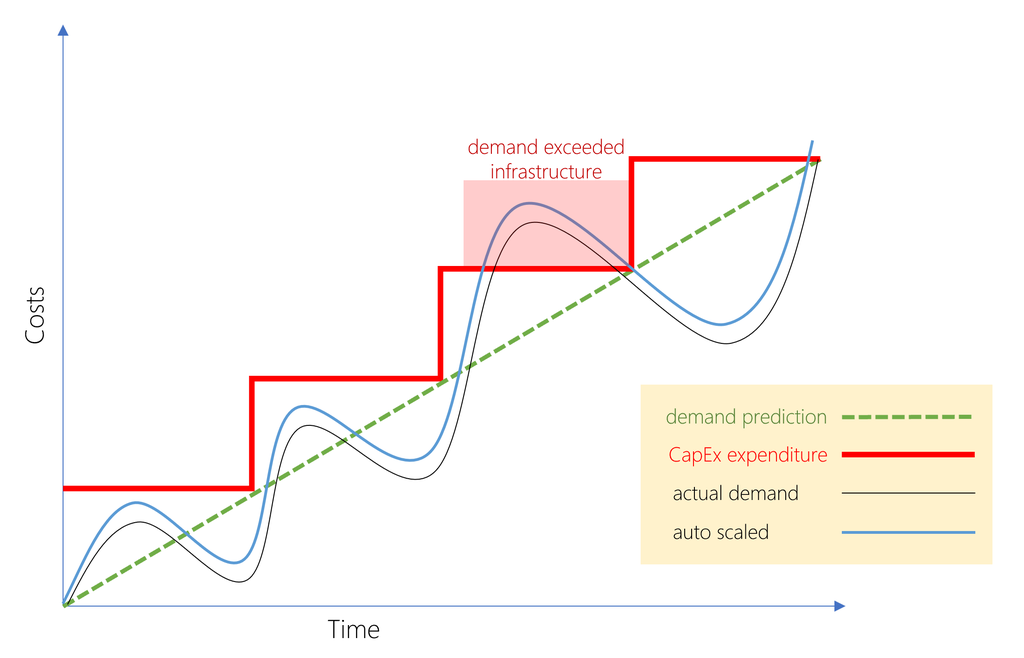

With the OpEx model, companies wanting to try a new product or service don't need to invest in equipment. Instead, they pay as much or as little for the infrastructure as required.

OpEx is particularly appealing if the demand fluctuates or is unknown. Cloud services are often said to be agile. **Cloud agility** is the ability to rapidly change an IT infrastructure to adapt to the evolving needs of the business. For example, if your service peaks one month, you can scale to demand and pay a larger bill for the month. If the following month the demand drops, you can reduce the used resources and be charged less. **This agility lets you manage your costs dynamically, optimizing spending as requirements change**.

### Topic 7: Cloud deployment models

There are three different cloud deployment models. **A cloud deployment model defines where your data is stored and how your customers interact with it** – how do they get to it, and where do the applications run? It also depends on how much of your own infrastructure you want or need to manage.

#### 7.1 Explore the three deployment methods of cloud computing

Public versus Private versus Hybrid

##### 7.1.1 Public cloud

[figure not shown]

This is the most common deployment model. In this case, you have **no local hardware** to manage or keep up-to-date – **everything runs on your cloud provider's hardware**. In some cases, you can save additional costs by sharing computing resources with other cloud users.

**Businesses can use multiple public cloud providers of varying scale**. Microsoft Azure is an example of a public cloud provider.

**Advantages**

A common use case scenario is **deploying a web application or a blog site** on hardware and resources that are owned by a cloud provider. Using a public cloud in this scenario allows cloud users to get their website or blog up quickly, and then focus on maintaining the site without having to worry about purchasing, managing or maintaining the hardware on which it runs.

**Disadvantages**

Not all scenarios fit the public cloud. Here are some disadvantages to think about:

- There may be specific security requirements that cannot be met by using public cloud
- There may be government policies, industry standards, or legal requirements which public clouds cannot meet
- You don't own the hardware or services and cannot manage them as you may want to
- Unique business requirements, such as having to maintain a legacy application might be hard to meet

##### 7.1.2 Private cloud

[figure not shown]

In a private cloud, you create a cloud environment in your own datacenter and provide self-service access to compute resources to users in your organization. This offers a simulation of a public cloud to your users, but you remain completely responsible for the purchase and maintenance of the hardware and software services you provide.

**Advantages**

This approach has several advantages:

- You can ensure the configuration can support any scenario or legacy application
- You have control (and responsibility) over security
- Private clouds can meet strict security, compliance, or legal requirements

**Disadvantages**

Some reasons teams move away from the private cloud are:

- You have some initial CapEx costs and must purchase the hardware for startup and maintenance
- Owning the equipment limits the agility - to scale you must buy, install, and setup new hardware
- Private clouds require IT skills and expertise that's hard to come by

A use case scenario for a private cloud would be when an organization has data that cannot be put in the public cloud, perhaps for legal reasons. An example scenario may be where government policy requires specific data to be kept in-country or privately.

A private cloud can provide cloud functionality to external customers as well, or to specific internal departments such as Accounting or Human Resources.

##### 7.1.3 Hybrid cloud

[figure not shown]

**A hybrid cloud combines public and private clouds**, allowing you to run your applications in the most appropriate location. For example, you could host a website in the public cloud and link it to a highly secure database hosted in your private cloud (or on-premises datacenter).

This is helpful when you have some things that cannot be put in the cloud, maybe for legal reasons. For example, you may have some specific pieces of data that cannot be exposed publicly (such as medical data) which needs to be held in your private datacenter. Another example is one or more applications that run on old hardware that can't be updated. In this case, you can keep the old system running locally, and connect it to the public cloud for authorization or storage.

**Advantages**

Some advantages of a hybrid cloud are:

- You can keep any systems running and accessible that use out-of-date hardware or an out-of-date operating system
- You have flexibility with what you run locally versus in the cloud
- You can take advantage of economies of scale from public cloud providers for services and resources where it's cheaper, and then supplement with your own equipment when it's not
- You can use your own equipment to meet security, compliance, or legacy scenarios where you need to completely control the environment

**Disadvantages**

Some concerns you'll need to watch out for are:

- It can be more expensive than selecting one deployment model since it involves some CapEx cost up front
- It can be more complicated to set up and manage

#### 7.2 Summary

Cloud computing is **flexible** and gives you the ability to choose how you want to deploy it. The cloud deployment model you choose depends on your budget, and on your security, scalability, and maintenance needs.

### Topic 8: Types of cloud services

When talking about cloud computing, there are three major categories. It's important to understand them because they are used in conversation, documentation, and training.

#### 8.1 Explore the three categories of cloud computing

IaaS versus SaaS versus PaaS

##### 8.1.1 Infrastructure as a service (IaaS)

[figure not shown]

**Infrastructure as a Service** is the **most flexible category of cloud services**. It aims to give you the **most control over the provided hardware that runs your application** (IT infrastructure servers and virtual machines (VMs), storage, and operating systems). Instead of buying hardware, with IaaS, you **rent** it. It's an instant computing infrastructure, provisioned and managed over the internet.

**Note**

When using IaaS, ensuring that a service is up and running is a shared responsibility: the **cloud provider** is **responsible for ensuring** the cloud infrastructure is **functioning correctly**; the cloud customer is responsible for ensuring the service they are using is **configured correctly**, is up to date, and is available to their customers. This is referred to as the **shared responsibility model**.

IaaS is commonly used in the following scenarios:

- **Migrating workloads**. Typically, IaaS facilities are managed in a similar way as on-premises infrastructure and provide an easy migration path for moving existing applications to the cloud.
- **Test and development**. Teams can quickly set up and dismantle test and development environments, bringing new applications to market faster. IaaS makes scaling development and testing environments, fast and economical.
- **Storage, backup, and recovery**. Organizations avoid the capital outlay and complexity of storage management, which typically requires skilled staff to manage data and meet legal and compliance requirements. IaaS is useful for **managing unpredictable demand and steadily growing storage needs**. IaaS can also simplify the planning and management of backup and recovery systems.

##### 8.1.2 Platform as a service (PaaS)

[figure not shown]

PaaS provides an environment for building, testing, and deploying software applications. The goal of PaaS is to help you create an application quickly without managing the underlying infrastructure. For example, **when deploying a web application using PaaS, you don't have to install an operating system, web server, or even system updates**.

PaaS is a complete development and deployment environment in the cloud, with resources that enable organizations to deliver everything from simple cloud-based apps to sophisticated cloud-enabled enterprise applications. Resources are purchased from a cloud service provider on a pay-as-you-go basis and accessed over a secure Internet connection.

PaaS is commonly used in the following scenarios:

- **Development framework**. PaaS provides a framework that developers can build upon to develop or customize cloud-based applications. Just like Microsoft Excel macro, PaaS lets developers create applications using built-in software components. Cloud features such as scalability, high-availability, and multi-tenant capability are included, reducing the amount of coding that developers must do.
- **Analytics or business intelligence**. Tools provided as a service with PaaS allow organizations to analyze and mine their data. They can find insights and patterns, and predict outcomes to improve business decisions such as forecasting, product design, and investment returns.

##### 8.1.3 Software as a service (SaaS)

SaaS is software that is centrally hosted and managed for the end customer. It is usually based on an architecture where one version of the application is used for all customers, and licensed through a monthly or annual subscription. Office 365, Skype, and Dynamics CRM Online are perfect examples of SaaS software.

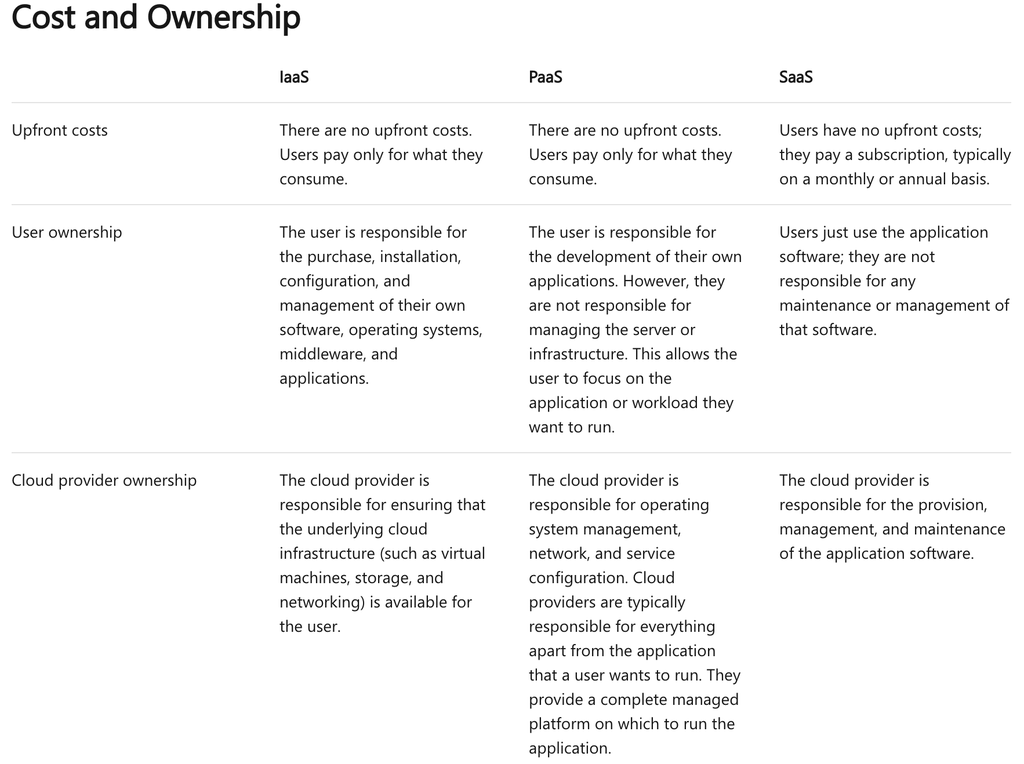

#### 8.2 Management responsibilities

One thing to understand is that **these categories are layers on top of each other**. For example, PaaS adds a layer on top of IaaS by providing a level of abstraction. The abstraction has the benefit of hiding the details that you may not care about, so that you can get to coding quicker. However, one aspect of the abstraction is that **you have less control over the underlying hardware**. The following illustration shows a list of resources that you manage and that your service provider manages in each cloud service category.

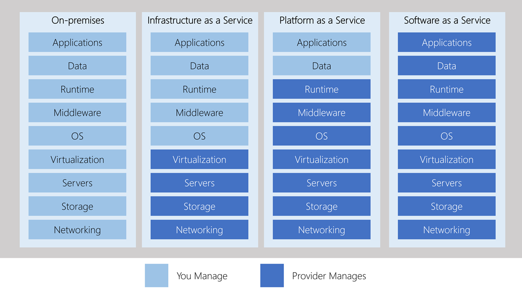

- IaaS **requires the most user management** of all the cloud services. The user is responsible for managing the *operating systems, data, and applications*.
- PaaS requires less user management. The cloud provider manages the operating systems, and the user is responsible for the *applications and data* they run and store.
- SaaS **requires the least amount of management**. The cloud provider is responsible for managing everything, and the **end user just uses the software**.

#### 8.3 Combine cloud services to fit your needs

IaaS, PaaS, and SaaS each contain different levels of managed services. You may easily use a combination of these types of infrastructure. You could use **Office 365** on your company's computers **(SaaS)**, and in Azure, you could host your **VMs (IaaS)** and use **Azure SQL Database (PaaS)** to store your data. With the cloud's flexibility, you can use any combination that provides you with the maximum result.

### Topic 9: Knowledge Check

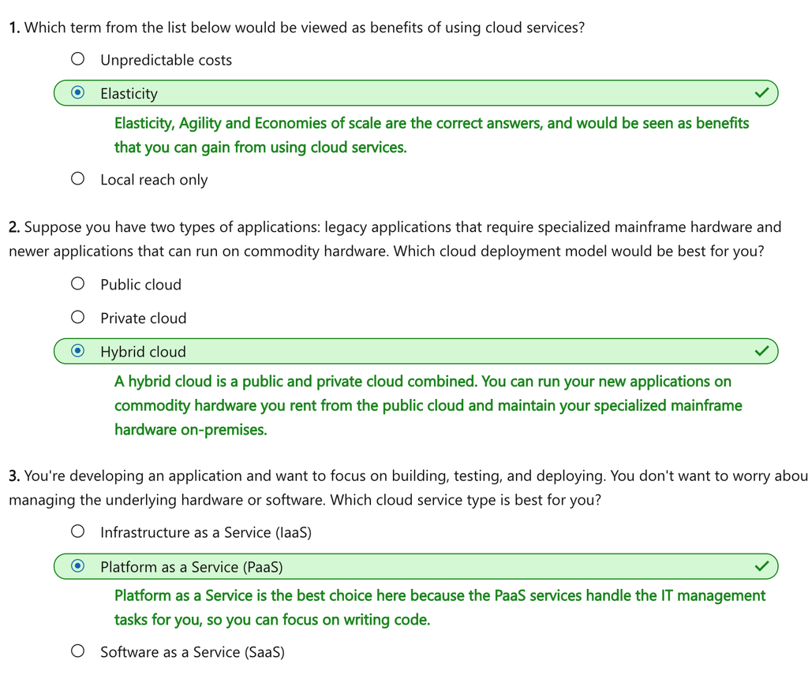

### Topic 10: Summary

In this module, you've learned about cloud computing, what it is and what its key characteristics are. Here are some of the things you covered.

- Different types of **cloud models** that are available and the considerations of using those different models.
- Some of the key terms and concepts such as high **availability**, **agility**, **elasticity**, **fault tolerance**, and **CapEx vs. OpEx**.
- The different **cloud services** available, the benefits of using the different types, and the **management responsibilities** under each service type.
- Cloud models such as **public**, **private** and **hybrid**, and what the key characteristics of each model are.
- The different types of cloud service available: **IaaS**, **PaaS**, and **SaaS**; what the key characteristics of each service are and when you would choose one over the other.

**Microsoft Azure**

Azure is Microsoft's **cloud computing platform**. Azure provides over 100 services that enable you to do everything from running your existing applications on virtual machines to exploring new software paradigms such as intelligent bots and mixed reality.

Here are just a few kinds of services you'll find on Azure:

- **Compute services** such as *VMs* and *containers* that can run your applications
- **Database services** that provide both *relational* and *NoSQL* choices
- **Identity services** that help you authenticate and protect your users
- **Networking services** that connect your datacenter to the cloud, provide high availability or host your DNS domain
- **Storage solutions** that can accommodate massive amounts of both *structured* and *unstructured* data
- **AI and machine-learning services** can analyze *data*, *text*, *images*, *comprehend speech*, and make *predictions* using data — changing the world of agriculture, healthcare, and much more.